# Plotting in conquestr

Dan Cloney

2025-08-23

# Introduction

*conquestr* has two main types of plotting functions:

- Functions for *rout* files created from the `plot` command in [ACER ConQuest](https://conquestmanual.acer.org/s4-00.html#plot). These plots are created using the generic function `conquestr::plotRout`. *rout* files are read in using the function `conquestr::ConQuestRout`.
- General plots, usually of the inputs or outputs of IRT estimation. These include for example:
  - Estimation history (*conquestr::plotCqHist*)
  - Wright maps based on system file (*conquestr::plotItemMap*)

# Example

## plotRout

This generic function, *plotRout*, will dispatch to specific methods depending on the class of the *rout* file. For example, in ConQuest if an ICC *rout* file is created, then when you call *plotRout*, the method *plotRout.ICC* will be called and an ICC will be returned.

```r
library(conquestr)
myRout <- ConQuestRout()
```

```
#> no rout file provided, loading the example rout file instead
```

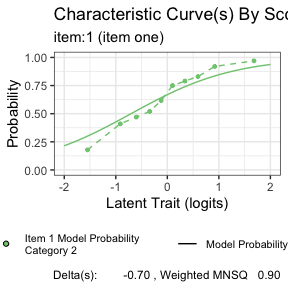

```r
myPlot <- plotRout(myRout)
myPlot
```

It is also to manually edit the returned object to do your own styling.

[figure not shown]

```r
library(gridExtra)
myPlot_themed <- myPlot + ggplot2::theme_dark()
myPlot_themed_new <- myPlot_themed
# remove geom_point layer
myPlot_themed_new$layers[[2]] <- NULL
grid.arrange(myPlot_themed, myPlot_themed_new)
```

## General Plots

You can plot an arbitrary information function against a distribution of students - a so called information Wright map.

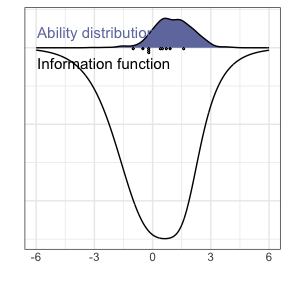

```r
myDeltaDots <- data.frame(
  id = c(1:10),
  itemid = paste0("item", 1:10),
  delta = rnorm(10)
)

MyTaus <- data.frame(
  id = c(2L, 10L),
  itemId = NA,
  step = c(1L, 1L),
  tau = rnorm(2)
)

myItemList <- makeItemList(deltaDot = myDeltaDots, tau = MyTaus)

myPersons <- rnorm(500, 1, 1)
informationWrightMap(myItems = myItemList, myAbilities = myPersons, minTheta = -6, maxTheta = 6)
```